# AI - CA4

## Arian Firoozi 810100196

```python
import numpy as np
import pandas
import seaborn
import matplotlib.pyplot as plt
```

## Dataset Analysis

1. Overall structure of dataset:

```python
dataset = pandas.read_csv("marketing_campaign.csv")
```

```python
dataset.info()
```

```
<class 'pandas.core.frame.DataFrame'>
RangeIndex: 2240 entries, 0 to 2239
Data columns (total 20 columns):
 #   Column             Non-Null Count  Dtype
---  ------             --------------  -----
 0   Unnamed: 0         2240 non-null   int64
 1   ID                 2240 non-null   int64
 2   Year_Birth         2240 non-null   int64
 3   Education          2240 non-null   object
 4   Marital_Status     2240 non-null   object
 5   Income             2017 non-null   float64
 6   Kidhome            2240 non-null   int64
 7   Teenhome           2240 non-null   int64
 8   Dt_Customer        2240 non-null   object
 9   Recency            2240 non-null   int64
 10  MntCoffee          2035 non-null   float64
 11  MntFruits          2240 non-null   int64
 12  MntMeatProducts    2240 non-null   int64
 13  MntFishProducts    2240 non-null   int64
 14  MntSweetProducts   2240 non-null   int64
 15  MntGoldProds       2227 non-null   float64
 16  NumWebVisitsMonth  2040 non-null   float64
 17  Complain           2240 non-null   int64
 18  NumPurchases       2240 non-null   int64
 19  UsedCampaignOffer  2240 non-null   int64
dtypes: float64(4), int64(13), object(3)
memory usage: 350.1+ KB
```

```python
dataset.describe()
```

|  | Unnamed: 0 | ID | Year_Birth | Income | Kidhome | Teenhome | Recency | MntCoffee | MntFruits | MntMeatProducts | MntFishProducts | MntSweetProducts | MntGoldProds | NumWebVisitsMonth | Complain | NumPurchases | UsedCampaignOffer |
| --- | --- | --- | --- | --- | --- | --- | --- | --- | --- | --- | --- | --- | --- | --- | --- | --- | --- |
| count | 2240.000000 | 2240.000000 | 2240.000000 | 2017.000000 | 2240.000000 | 2240.000000 | 2240.000000 | 2035.000000 | 2240.000000 | 2240.000000 | 2240.000000 | 2240.000000 | 2227.000000 | 2040.000000 | 2240.000000 | 2240.000000 | 2240.000000 |
| mean | 1119.500000 | 5592.159821 | 1968.805804 | 52297.080317 | 0.437946 | 0.506250 | 49.109375 | 304.239312 | 26.302232 | 166.950000 | 37.525446 | 27.062946 | 43.847777 | 5.326961 | 0.009375 | 14.862054 | 0.271875 |
| std | 646.776623 | 3246.662198 | 11.984069 | 25543.108215 | 0.563666 | 0.544538 | 28.962453 | 337.515534 | 39.773434 | 225.715373 | 54.628979 | 41.280498 | 51.897098 | 2.439349 | 0.096391 | 7.677173 | 0.445025 |
| min | 0.000000 | 0.000000 | 1893.000000 | 2447.000000 | -5.000000 | 0.000000 | 0.000000 | 0.000000 | 0.000000 | 0.000000 | 0.000000 | 0.000000 | 0.000000 | 0.000000 | 0.000000 | 0.000000 | 0.000000 |
| 25% | 559.750000 | 2828.250000 | 1959.000000 | 35340.000000 | 0.000000 | 0.000000 | 24.000000 | 23.000000 | 1.000000 | 16.000000 | 3.000000 | 1.000000 | 9.000000 | 3.000000 | 0.000000 | 8.000000 | 0.000000 |
| 50% | 1119.500000 | 5458.500000 | 1970.000000 | 51369.000000 | 0.000000 | 0.000000 | 49.000000 | 177.000000 | 8.000000 | 67.000000 | 12.000000 | 8.000000 | 24.000000 | 6.000000 | 0.000000 | 15.000000 | 0.000000 |
| 75% | 1679.250000 | 8427.750000 | 1977.000000 | 68316.000000 | 1.000000 | 1.000000 | 74.000000 | 505.000000 | 33.000000 | 232.000000 | 50.000000 | 33.000000 | 56.000000 | 7.000000 | 0.000000 | 21.000000 | 1.000000 |
| max | 2239.000000 | 11191.000000 | 1996.000000 | 666666.000000 | 2.000000 | 2.000000 | 99.000000 | 1493.000000 | 199.000000 | 1725.000000 | 259.000000 | 263.000000 | 362.000000 | 20.000000 | 1.000000 | 44.000000 | 1.000000 |

2. Finding nulls:

```python
null_num = dataset.isnull().sum()
display(null_num.to_frame().transpose())
```

|  | Unnamed: 0 | ID | Year_Birth | Education | Marital_Status | Income | Kidhome | Teenhome | Dt_Customer | Recency | MntCoffee | MntFruits | MntMeatProducts | MntFishProducts | MntSweetProducts | MntGoldProds | NumWebVisitsMonth | Complain | NumPurchases | UsedCampaignOffer |
| --- | --- | --- | --- | --- | --- | --- | --- | --- | --- | --- | --- | --- | --- | --- | --- | --- | --- | --- | --- | --- |
| 0 | 0 | 0 | 0 | 0 | 0 | 223 | 0 | 0 | 0 | 0 | 205 | 0 | 0 | 0 | 0 | 13 | 200 | 0 | 0 | 0 |

```python
null_percent = null_num.copy()

for attr in dataset.columns:
    null_percent[attr] /= dataset[attr].count()
    null_percent[attr] *= 100

display(null_percent.to_frame().transpose())
```

|  | Unnamed: 0 | ID | Year_Birth | Education | Marital_Status | Income | Kidhome | Teenhome | Dt_Customer | Recency | MntCoffee | MntFruits | MntMeatProducts | MntFishProducts | MntSweetProducts | MntGoldProds | NumWebVisitsMonth | Complain | NumPurchases | UsedCampaignOffer |
| --- | --- | --- | --- | --- | --- | --- | --- | --- | --- | --- | --- | --- | --- | --- | --- | --- | --- | --- | --- | --- |
| 0 | 0.0 | 0.0 | 0.0 | 0.0 | 0.0 | 11.056024 | 0.0 | 0.0 | 0.0 | 0.0 | 10.07371 | 0.0 | 0.0 | 0.0 | 0.0 | 0.583745 | 9.803922 | 0.0 | 0.0 | 0.0 |

3. Correlation of attributes are shown below. Top 3 most correlated columns are considered as high correlation columns.

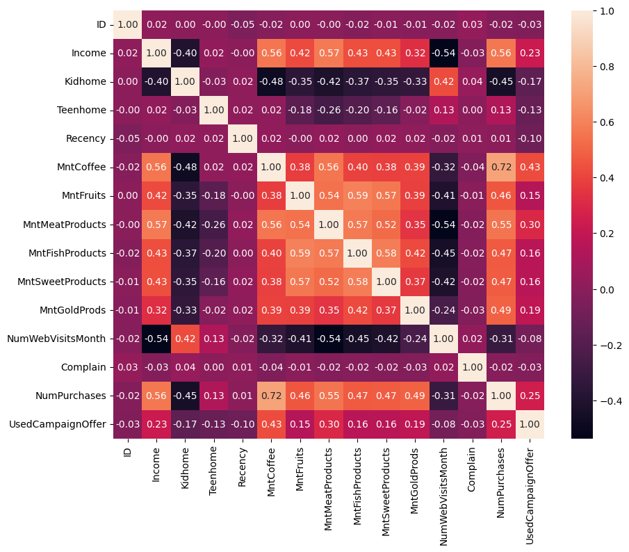

```python
heatmap = pandas.DataFrame(dataset, columns = ['ID', 'Income', 'Kidhome', 'Teenhome', 'Recency', 'MntCoffee', 'MntFruits','MntMeatProducts','MntFishProducts','MntSweetProducts','MntGoldProds','NumWebVisitsMonth','Complain','NumPurchases','UsedCampaignOffer'])
plt.figure(figsize=(10,8))
plt.show(seaborn.heatmap(heatmap.corr(), annot=True, fmt = '.2f'))
```

```python
purchase_corr = heatmap.corr()['NumPurchases'].sort_values(ascending=False, key=lambda x: abs(x))[1:]
display(purchase_corr.to_frame().transpose())
```

|  | MntCoffee | Income | MntMeatProducts | MntGoldProds | MntSweetProducts | MntFishProducts | MntFruits | Kidhome | NumWebVisitsMonth | UsedCampaignOffer | Teenhome | ID | Complain | Recency |
| --- | --- | --- | --- | --- | --- | --- | --- | --- | --- | --- | --- | --- | --- | --- |
| NumPurchases | 0.715164 | 0.562603 | 0.554229 | 0.493939 | 0.472876 | 0.469454 | 0.455461 | -0.447073 | -0.309666 | 0.251386 | 0.133163 | -0.023834 | -0.020583 | 0.00574 |

4. Individual observations:

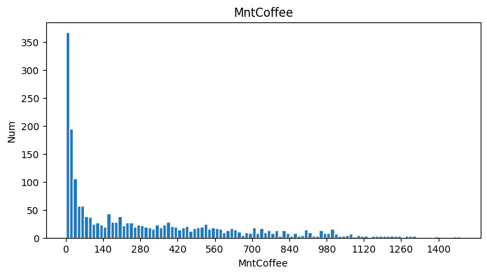

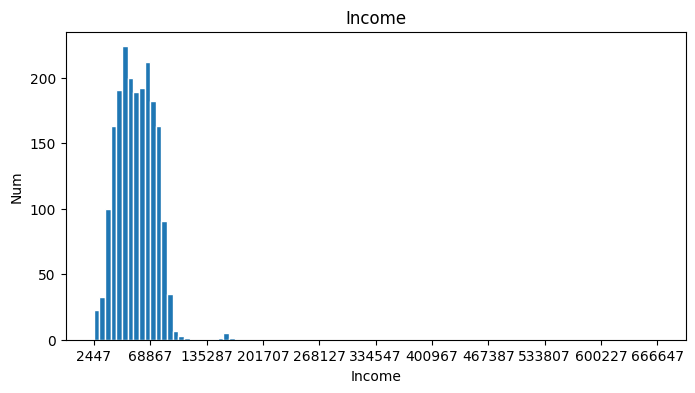

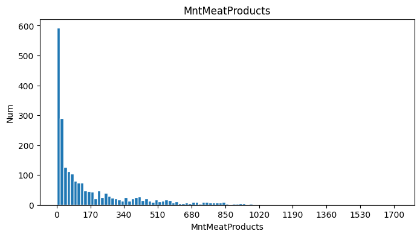

```python
for item in purchase_corr.index[0:3]:
    bins = np.arange(dataset[item].min(), dataset[item].max())
    plt.figure(figsize=(8, 4))
    plt.xticks(bins[::max(len(bins)//100 * 10, 1)])
    plt.title(item)
    plt.ylabel('Num')
    plt.xlabel(item)
    plt.hist(dataset[item], bins[::max(len(bins)//100,1)], edgecolor='white')
    plt.show()
```

5. Both diagrams show correlation between number of purchases and other data. Scatter diagram displays raw data while hexbin shows density of distribution as well. Since data is raw, outlier data is still present in diagrams and plots do not show exact correlation.

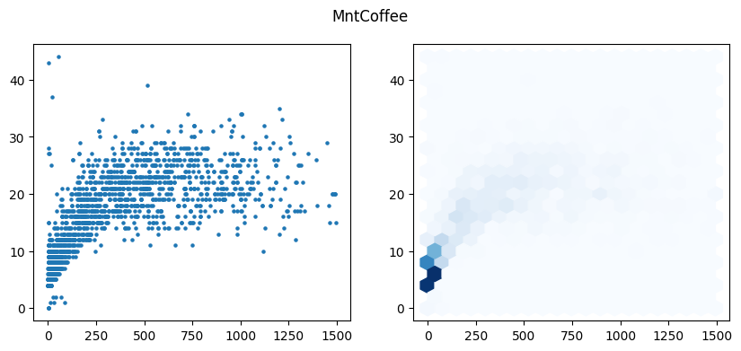

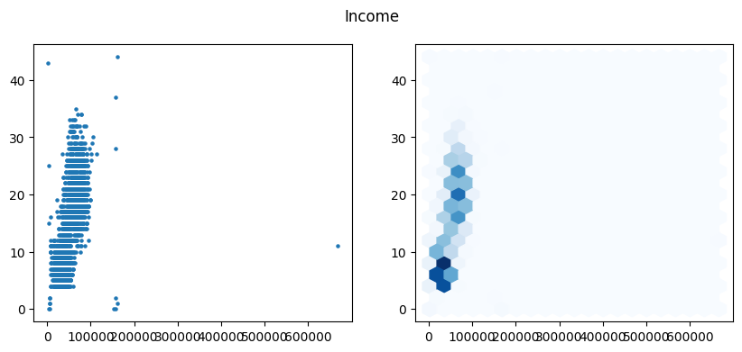

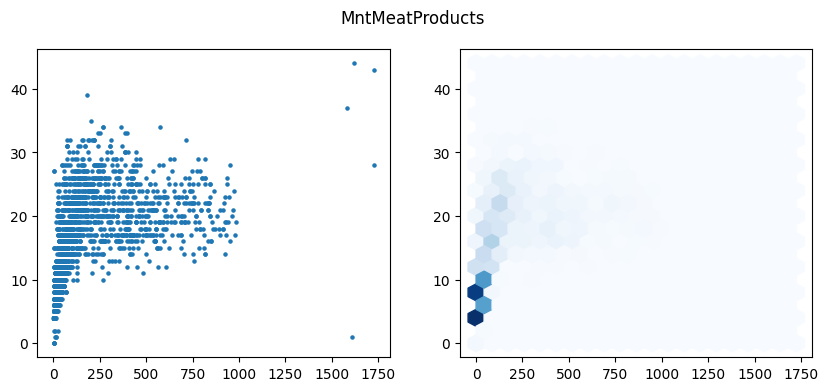

```python
for item in purchase_corr.index[0:3]:
    _, cols = plt.subplots(ncols=2, figsize=(10, 4))
    plt.suptitle(item)
    cols[0].scatter(dataset[item], dataset["NumPurchases"], s=5)
    cols[1].hexbin(dataset[item], dataset["NumPurchases"], gridsize=20, cmap="Blues")
    plt.show()
```

## Preprocess

7. There are many ways to fill NaN data; For example, a simple approach is to fill the missing data by backward and forward filling method which simply replaces the missing data with the first data before or after NaN value, but it's obvious that this method is not the optimal solution for our problem. Interpolation and ML-based techniques can be used to solve this issue as well. Replacing values by ML techniques is often time consuming and hard to implement while removing the whole row or column because of missing data, is not considered optimal since we are missing a lot of information. In most situations it's enough to replace missing values by imputation or interpolation techniques.
8. based on results in q2, most frequently missing values are from income, mntcoffee and number of website visits per month. since the first two features happen to highly correlate with purchases, we cannot simply delete the entire column and it's better to use replacement techniques. Code for imputing missing values is implemented below:

```python
dataset_fillna = dataset.fillna(dataset.mean(numeric_only=True))
```

```python
null_num_impute = dataset_fillna.isnull().sum()
display(null_num_impute.to_frame().transpose())
```

|  | Unnamed: 0 | ID | Year_Birth | Education | Marital_Status | Income | Kidhome | Teenhome | Dt_Customer | Recency | MntCoffee | MntFruits | MntMeatProducts | MntFishProducts | MntSweetProducts | MntGoldProds | NumWebVisitsMonth | Complain | NumPurchases | UsedCampaignOffer |
| --- | --- | --- | --- | --- | --- | --- | --- | --- | --- | --- | --- | --- | --- | --- | --- | --- | --- | --- | --- | --- |
| 0 | 0 | 0 | 0 | 0 | 0 | 0 | 0 | 0 | 0 | 0 | 0 | 0 | 0 | 0 | 0 | 0 | 0 | 0 | 0 | 0 |

9. Normalization is a scaling technique, scaling all the values to 0 to 1 range. This method is sensitive to outlier data which are present in our dataset.

   Standardization technique scales and centers data. Standardized dataset will be centered around mean with a standard deviation of 1. This method is more effective on data with Gaussian distribution.

   Distribution of most important features that we calculated in q3 is not Gaussian as plotted in q4 (except for income), but since there are outlier values that can affect final results, standardization seems to be more preferable.

```python
from sklearn.preprocessing import StandardScaler

def standardize(data: pandas.DataFrame, exclude):
    scalar = StandardScaler()
    standard_data = data.copy()
    standard_data[data.select_dtypes(include='number').columns] = scalar.fit_transform(data.select_dtypes(include='number'))
    standard_data[exclude] = data[exclude]
    return standard_data

standard_data = standardize(dataset_fillna, 'NumPurchases')
display(standard_data)
```

|  | Unnamed: 0 | ID | Year_Birth | Education | Marital_Status | Income | Kidhome | Teenhome | Dt_Customer | Recency | MntCoffee | MntFruits | MntMeatProducts | MntFishProducts | MntSweetProducts | MntGoldProds | NumWebVisitsMonth | Complain | NumPurchases | UsedCampaignOffer |
| --- | --- | --- | --- | --- | --- | --- | --- | --- | --- | --- | --- | --- | --- | --- | --- | --- | --- | --- | --- | --- |
| 0 | -1.731278 | -0.020999 | -0.985345 | Graduation | Single | 0.241038 | -0.777134 | -0.929894 | 4/9/2012 | 0.307039 | 1.028416 | 1.551577 | 1.679702 | 2.462147 | 1.476500 | 0.853436 | 0.000000 | -0.097282 | 25 | 1.636509 |
| 1 | -1.729731 | -1.053058 | -1.235733 | Graduation | Single | -0.245667 | 0.997361 | 0.906934 | 8/3/2014 | -0.383664 | 0.000000 | -0.636301 | -0.713225 | -0.650449 | -0.631503 | -0.731575 | -0.140487 | -0.097282 | 6 | -0.611057 |
| 2 | -1.728185 | -0.447070 | -0.317643 | Graduation | Together | 0.797114 | -0.777134 | -0.929894 | 21-08-2013 | -0.798086 | 0.000000 | 0.570804 | -0.177032 | 1.345274 | -0.146905 | -0.035716 | 0.000000 | -0.097282 | 21 | -0.611057 |
| 3 | -1.726638 | 0.181716 | 1.268149 | Graduation | Together | -1.058548 | 0.997361 | -0.929894 | 10/2/2014 | -0.798086 | -0.911752 | -0.560857 | -0.651187 | -0.503974 | -0.583043 | -0.750904 | 0.289189 | -0.097282 | 8 | -0.611057 |
| 4 | -1.725092 | -0.082614 | 1.017761 | PhD | Married | 0.247435 | 0.997361 | -0.929894 | 19-01-2014 | 1.550305 | -0.408055 | 0.419916 | -0.216914 | 0.155164 | -0.001525 | -0.557610 | -0.140487 | -0.097282 | 19 | -0.611057 |
| ... | ... | ... | ... | ... | ... | ... | ... | ... | ... | ... | ... | ... | ... | ... | ... | ... | ... | ... | ... | ... |
| 2235 | 1.725092 | 1.625983 | -0.150717 | Graduation | Married | 0.368348 | -0.777134 | 0.906934 | 13-06-2013 | -0.107383 | 1.258500 | 0.419916 | 0.066692 | 0.081926 | 2.203398 | 3.926810 | -0.140487 | -0.097282 | 18 | -0.611057 |
| 2236 | 1.726638 | -0.490200 | -1.903435 | PhD | Together | 0.483524 | 2.771857 | 0.906934 | 10/6/2014 | 0.237969 | 0.316399 | -0.661449 | -0.606873 | -0.687068 | -0.655733 | -0.692916 | 0.718865 | -0.097282 | 22 | 1.636509 |
| 2237 | 1.728185 | 0.516905 | 1.017761 | Graduation | Divorced | 0.193292 | -0.777134 | -0.929894 | 25-01-2014 | 1.446700 | 1.877239 | 0.545656 | 0.221789 | -0.101168 | -0.364974 | -0.383646 | 0.289189 | -0.097282 | 19 | 1.636509 |
| 2238 | 1.729731 | 0.814199 | -1.068807 | Master | Together | 0.699393 | -0.777134 | 0.906934 | 24-01-2014 | -1.419719 | 0.384802 | 0.092992 | 0.208495 | 0.777683 | 0.071165 | 0.331542 | 0.000000 | -0.097282 | 23 | -0.611057 |
| 2239 | 1.731278 | 1.174650 | -1.235733 | PhD | Married | 0.023602 | 0.997361 | 0.906934 | 15-10-2012 | -0.314594 | -0.684778 | -0.586005 | -0.469501 | -0.650449 | -0.631503 | -0.441634 | 0.718865 | -0.097282 | 11 | 1.636509 |

2240 rows × 20 columns

10. Categorical values are those that are not represented by numbers, but with strings or objects. In the dataset used in this project, columns Education, Martial_Status and Dt_Customer fall into this category. Many methods can be used for preprocessing this kind of data include:
    - One Hot Encoding: For each category, we assign a column that has values 1 or 0. Value 1 shows that the row is in the category assigned to the column.
    - Label Encoding: Assigning a number between 1 to N-1 for each of N categories and showing the values in a single column.
    - Hashing: Using a hash function to assign numbers to each category. This method can be effective if space usage is important.
    - Frequency Encoding: each category is replaced by its appearance frequency in dataset. This method is useful if we need to fill in missing values after coding.

Here is an implementation of label encoding for dataset:

```python
import category_encoders
encoded_dataset = standard_data.copy()
categorical_cols = encoded_dataset.select_dtypes(include=['object'])
encoded_dataset[categorical_cols.columns] = category_encoders.OrdinalEncoder(cols=categorical_cols).fit_transform(categorical_cols)
encoded_dataset
```

|  | Unnamed: 0 | ID | Year_Birth | Education | Marital_Status | Income | Kidhome | Teenhome | Dt_Customer | Recency | MntCoffee | MntFruits | MntMeatProducts | MntFishProducts | MntSweetProducts | MntGoldProds | NumWebVisitsMonth | Complain | NumPurchases | UsedCampaignOffer |
| --- | --- | --- | --- | --- | --- | --- | --- | --- | --- | --- | --- | --- | --- | --- | --- | --- | --- | --- | --- | --- |
| 0 | -1.731278 | -0.020999 | -0.985345 | 1 | 1 | 0.241038 | -0.777134 | -0.929894 | 1 | 0.307039 | 1.028416 | 1.551577 | 1.679702 | 2.462147 | 1.476500 | 0.853436 | 0.000000 | -0.097282 | 25 | 1.636509 |
| 1 | -1.729731 | -1.053058 | -1.235733 | 1 | 1 | -0.245667 | 0.997361 | 0.906934 | 2 | -0.383664 | 0.000000 | -0.636301 | -0.713225 | -0.650449 | -0.631503 | -0.731575 | -0.140487 | -0.097282 | 6 | -0.611057 |
| 2 | -1.728185 | -0.447070 | -0.317643 | 1 | 2 | 0.797114 | -0.777134 | -0.929894 | 3 | -0.798086 | 0.000000 | 0.570804 | -0.177032 | 1.345274 | -0.146905 | -0.035716 | 0.000000 | -0.097282 | 21 | -0.611057 |
| 3 | -1.726638 | 0.181716 | 1.268149 | 1 | 2 | -1.058548 | 0.997361 | -0.929894 | 4 | -0.798086 | -0.911752 | -0.560857 | -0.651187 | -0.503974 | -0.583043 | -0.750904 | 0.289189 | -0.097282 | 8 | -0.611057 |
| 4 | -1.725092 | -0.082614 | 1.017761 | 2 | 3 | 0.247435 | 0.997361 | -0.929894 | 5 | 1.550305 | -0.408055 | 0.419916 | -0.216914 | 0.155164 | -0.001525 | -0.557610 | -0.140487 | -0.097282 | 19 | -0.611057 |
| ... | ... | ... | ... | ... | ... | ... | ... | ... | ... | ... | ... | ... | ... | ... | ... | ... | ... | ... | ... | ... |
| 2235 | 1.725092 | 1.625983 | -0.150717 | 1 | 3 | 0.368348 | -0.777134 | 0.906934 | 226 | -0.107383 | 1.258500 | 0.419916 | 0.066692 | 0.081926 | 2.203398 | 3.926810 | -0.140487 | -0.097282 | 18 | -0.611057 |
| 2236 | 1.726638 | -0.490200 | -1.903435 | 2 | 2 | 0.483524 | 2.771857 | 0.906934 | 575 | 0.237969 | 0.316399 | -0.661449 | -0.606873 | -0.687068 | -0.655733 | -0.692916 | 0.718865 | -0.097282 | 22 | 1.636509 |
| 2237 | 1.728185 | 0.516905 | 1.017761 | 1 | 4 | 0.193292 | -0.777134 | -0.929894 | 441 | 1.446700 | 1.877239 | 0.545656 | 0.221789 | -0.101168 | -0.364974 | -0.383646 | 0.289189 | -0.097282 | 19 | 1.636509 |
| 2238 | 1.729731 | 0.814199 | -1.068807 | 3 | 2 | 0.699393 | -0.777134 | 0.906934 | 103 | -1.419719 | 0.384802 | 0.092992 | 0.208495 | 0.777683 | 0.071165 | 0.331542 | 0.000000 | -0.097282 | 23 | -0.611057 |
| 2239 | 1.731278 | 1.174650 | -1.235733 | 2 | 3 | 0.023602 | 0.997361 | 0.906934 | 215 | -0.314594 | -0.684778 | -0.586005 | -0.469501 | -0.650449 | -0.631503 | -0.441634 | 0.718865 | -0.097282 | 11 | 1.636509 |

2240 rows × 20 columns

```python
dropped_dataset = encoded_dataset.drop(columns=['Unnamed: 0', 'ID', 'Dt_Customer'])
dropped_dataset.drop(columns=purchase_corr[::-1][:2].to_dict().keys())
```

|  | Year_Birth | Education | Marital_Status | Income | Kidhome | Teenhome | MntCoffee | MntFruits | MntMeatProducts | MntFishProducts | MntSweetProducts | MntGoldProds | NumWebVisitsMonth | NumPurchases | UsedCampaignOffer |
| --- | --- | --- | --- | --- | --- | --- | --- | --- | --- | --- | --- | --- | --- | --- | --- |
| 0 | -0.985345 | 1 | 1 | 0.241038 | -0.777134 | -0.929894 | 1.028416 | 1.551577 | 1.679702 | 2.462147 | 1.476500 | 0.853436 | 0.000000 | 25 | 1.636509 |
| 1 | -1.235733 | 1 | 1 | -0.245667 | 0.997361 | 0.906934 | 0.000000 | -0.636301 | -0.713225 | -0.650449 | -0.631503 | -0.731575 | -0.140487 | 6 | -0.611057 |
| 2 | -0.317643 | 1 | 2 | 0.797114 | -0.777134 | -0.929894 | 0.000000 | 0.570804 | -0.177032 | 1.345274 | -0.146905 | -0.035716 | 0.000000 | 21 | -0.611057 |
| 3 | 1.268149 | 1 | 2 | -1.058548 | 0.997361 | -0.929894 | -0.911752 | -0.560857 | -0.651187 | -0.503974 | -0.583043 | -0.750904 | 0.289189 | 8 | -0.611057 |
| 4 | 1.017761 | 2 | 3 | 0.247435 | 0.997361 | -0.929894 | -0.408055 | 0.419916 | -0.216914 | 0.155164 | -0.001525 | -0.557610 | -0.140487 | 19 | -0.611057 |
| ... | ... | ... | ... | ... | ... | ... | ... | ... | ... | ... | ... | ... | ... | ... | ... |
| 2235 | -0.150717 | 1 | 3 | 0.368348 | -0.777134 | 0.906934 | 1.258500 | 0.419916 | 0.066692 | 0.081926 | 2.203398 | 3.926810 | -0.140487 | 18 | -0.611057 |
| 2236 | -1.903435 | 2 | 2 | 0.483524 | 2.771857 | 0.906934 | 0.316399 | -0.661449 | -0.606873 | -0.687068 | -0.655733 | -0.692916 | 0.718865 | 22 | 1.636509 |
| 2237 | 1.017761 | 1 | 4 | 0.193292 | -0.777134 | -0.929894 | 1.877239 | 0.545656 | 0.221789 | -0.101168 | -0.364974 | -0.383646 | 0.289189 | 19 | 1.636509 |
| 2238 | -1.068807 | 3 | 2 | 0.699393 | -0.777134 | 0.906934 | 0.384802 | 0.092992 | 0.208495 | 0.777683 | 0.071165 | 0.331542 | 0.000000 | 23 | -0.611057 |
| 2239 | -1.235733 | 2 | 3 | 0.023602 | 0.997361 | 0.906934 | -0.684778 | -0.586005 | -0.469501 | -0.650449 | -0.631503 | -0.441634 | 0.718865 | 11 | 1.636509 |

2240 rows × 15 columns

12. Here are a few methods to split data:
    - Random split: randomly splitting data to test and train sets.
    - Stratified split: splitting data to test and train while making sure that distribution of target label is same in both train and test data sets.
    - Time series split: setting a certain time and using observations made before that time as train set and assigning future events as test set. This method is only useful when data is time-dependent.

    Recommended test percentage is usually between 20-30 percent of all of the dataset. In this project a 20-80 data split is implemented.

    A random test and split are implemented below.

```python
import random

TEST_PERCENT = 20
random.seed(196)

def get_train_test(data: pandas.DataFrame):
    test_num = int(len(data) * TEST_PERCENT / 100)
    test = random.sample(range(len(data)), test_num)
    train = np.setdiff1d([i for i in range(len(data))], test)
    return data.iloc[train], data.iloc[test]

train, test = get_train_test(dropped_dataset)
```

13. Validation set is a technique used to prevent overfitting. When training the model, it can learn to recognize noises as features and overfitting occur. To prevent this, a validation set can be used to validate performance of the model during the training phase.
14. In this method, dataset is divided into k sets and we perform test-train on each of these k sets. After training over every set, results are combined and final model forms. This is a complicated method for training and despite avoiding overfitting very well, it takes a long time to train the model.

## Phase 1: Linear Regression

Main form of simple linear regression function: $$f(x) = \alpha x + \beta$$

- step 1: Compute RSS of the training data

$$ RSS = \Sigma (y_i - (\hat{\beta} + \hat{\alpha} * x_i) )^2 $$

- step 2: Compute the derivatives of the RSS function in terms of $\alpha$ and $\beta$, and set them equal to 0 to find the desired parameters

$$ \frac{\partial RSS}{\partial \beta} = \Sigma (-f(x_i) + \hat{\beta} + \hat{\alpha} * x_i) = 0$$ $$ \to \beta = \hat{y} - \hat{\alpha} \hat{x} \to (1)$$

$$ \frac{\partial RSS}{\partial \alpha} = \Sigma (-2 x_i y_i + 2 \hat{\beta} x_i + 2\hat{\alpha} x_i ^ 2) = 0 \to (2)$$

$$ (1) , (2) \to \hat{\alpha} = \frac{\Sigma{(x_i - \hat{x})(y_i - \hat{y})}}{\Sigma{(x_i - \hat{x})^2}} $$ $$ \hat{\beta} = y - \hat{a} x$$

15. Based on the above formula, a function is implemented below to compute the parameters of a simple linear regression

```python
def simple_linear_regression(input_feature, output):
    inp_len = len(input_feature)
    in_sum = input_feature.sum()
    out_sum = output.sum()
    product = (input_feature * output).sum()
    in2_sum = (input_feature**2).sum()

    slope = (product - in_sum * out_sum / inp_len) / (in2_sum - in_sum**2 / inp_len)
    bias = (out_sum - slope*in_sum) / inp_len

    return bias, slope
```

```python
def get_regression_predictions(input_feature, bias, slope):
    return input_feature * slope + bias
```

16. Since there is only one feature to be used to predict the regression function, we need to use the feature with highest correlation. According to results we obtained previously, Mnt_Coffee is the most suitable feature for this purpose.

```python
def get_root_mean_square_error(predicted_values, outputs):
    mean2 = ((outputs - predicted_values)**2).sum() / len(predicted_values)
    return mean2**0.5
```

```python
def get_r2_score(predicted_values, outputs):
    ss_res = ((predicted_values - outputs)**2).sum()
    out_mean = outputs.sum()/len(outputs)
    ss_tot = ((outputs - out_mean)**2).sum()

    return 1-ss_res/ss_tot
```

```python
train, test = get_train_test(dropped_dataset)

def display_results(predicted, feature, output):
    print(feature)
    rmse = get_root_mean_square_error(predicted, output)
    print('RMSE score is',rmse)
    r2 = get_r2_score(predicted, output)
    print('R2 score is', r2)

def get_linear_regression_prediction(feature):
    input = train[feature]
    output = train['NumPurchases']
    bias, slope = simple_linear_regression(input, output)

    input, output = test[feature], test['NumPurchases']
    predicted = get_regression_predictions(input, bias, slope)

    return predicted

designated_feature_list = [purchase_corr.index[0]]
predicted = get_linear_regression_prediction(designated_feature_list[0])
display_results(predicted, designated_feature_list[0], test['NumPurchases'])
```

```
MntCoffee
RMSE score is 5.886722658252739
R2 score is 0.4322154898266768
```

17. RSS: Shows total variance of predictions, formula is given above. MSE: A measure to calculate average magnitude of errors. We can calculate this by dividing RSS by number of predictions. RMSE: Square root of MSE measure. It eliminates the squared root effect in MSE measure, giving a better feeling of error magnitude. R2: Gives a score between 1 to 0, the closer the score gets to 1, model works better. An R2 score above 0.5 is generally considered acceptable for the model.

```python
designated_feature_list = [purchase_corr.index[i] for i in range(5)]
for feature in designated_feature_list:
    predicted = get_linear_regression_prediction(feature)
    display_results(predicted, feature, test['NumPurchases'])
```

```
MntCoffee
RMSE score is 5.886722658252739
R2 score is 0.4322154898266768
Income
RMSE score is 6.003608456549228
R2 score is 0.40944396642309044
MntMeatProducts
RMSE score is 6.3896539651143245
R2 score is 0.3310539889880607
MntGoldProds
RMSE score is 6.88543252755212
R2 score is 0.22321855441847327
MntSweetProducts
RMSE score is 7.05597321447697
R2 score is 0.18426285874683768
```

## Phase 2: Multiple Regression

Multiple regression is a statistical technique that aims to model the relationship between a dependent variable and two or more independent variables.

Multiple regression with n independent variables is expressed as follows:

$$f(x) = \beta _{0} + \beta_{1} x_{1} + \beta_{2} x_{2} + \beta_{3} x_{3} + \beta_{4} x_{4} + ... + \beta_{n} x_{n} + c $$

To optimize the model for accurate predictions, multiple regression commonly employs iterative algorithms such as gradient descent.

The main goal of the optimization process is to make our predictions as close as possible to the actual values. We measure the prediction error using a cost function, usually denoted as $J(\beta)$.

$$ J(\beta)= \frac {1}{2m} Σ_{i=0}^{m-1}(y_i - (\hat \beta _{0} + \hat \beta_{1} x_{1} + \hat \beta_{2} x_{2} + \hat \beta_{3} x_{3} + \hat \beta_{4} x_{4} + ... + \hat \beta_{n} x_{n}) )^2 $$

Gradient descent iteratively adjusts the coefficients $(\beta_i)$ to minimize the cost function. The update rule for each coefficient is:

$$\beta_{i} = \beta _ {i} - \alpha \frac {∂J(\beta)}{∂\beta_{i}}$$

$$ \frac {∂J(\beta)}{∂\beta_{i}} = \frac {1}{m}Σ_{j=0}^{m-1}(y_j - (\hat \beta _{0} + \hat \beta_{1} x_{j1} + \hat \beta_{2} x_{j2} + \hat \beta_{3} x_{j3} + \hat \beta_{4} x_{j4} + ... + \hat \beta_{n} x_{jn})) x_{ji} $$

```python
def predict_output(feature_matrix, weights, bias):
    prediction_list = np.dot(feature_matrix, weights)
    return prediction_list + bias
```

### Derivatives:

As we saw, the cost function is the sum over the data points of the squared difference between an observed output and a predicted output.

Since the derivative of a sum is the sum of the derivatives, we can compute the derivative for a single data point and then sum over data points. We can write the squared difference between the observed output and predicted output for a single point as follows:

$$ (output - (const* w _{0} + [feature_1] * w_{1} + ...+ [feature_n] * w_{n} ))^2 $$

With n feautures and a const , So the derivative will be :

$$ 2 * (output - (const* w _{0} + [feature_1] * w_{1} + ...+ [feature_n] * w_{n} )) $$

The term inside the paranethesis is just the error (difference between prediction and output). So we can re-write this as:

$$2 * error*[feature_i] $$

That is, the derivative for the weight for feature i is the sum (over data points) of 2 times the product of the error and the feature itself. In the case of the constant then this is just twice the sum of the errors!

Recall that twice the sum of the product of two vectors is just twice the dot product of the two vectors. Therefore the derivative for the weight for feature_i is just two times the dot product between the values of feature_i and the current errors.

```python
def feature_derivative(errors, feature):
    return np.dot(errors, feature) * 2
```

### Gradient Descent

Now we will write a function that performs a gradient descent. The basic premise is simple. Given a starting point we update the current weights by moving in the negative gradient direction. Recall that the gradient is the direction of increase and therefore the negative gradient is the direction of decrease and we're trying to minimize a cost function.

The amount by which we move in the negative gradient direction is called the 'step size'. We stop when we are 'sufficiently close' to the optimum. We define this by requiring that the magnitude (length) of the gradient vector to be smaller than a fixed 'tolerance'.

```python
def regression_gradient_descent(feature_matrix, output, initial_weights, bias, step_size, tolerance):
    weights = initial_weights
    while True:
        predictions = predict_output(feature_matrix, weights, bias)
        errors = predictions - output
        derivatives = [feature_derivative(errors, feature_matrix[:, i]) for i in range(len(weights))]

        weights = [weights[i] - step_size * derivatives[i] for i in range(len(weights))]

        bias -= step_size * feature_derivative(errors, np.ones(len(errors)))

        grad = (np.sum([derivatives[i]**2 for i in range(len(weights))]) )**0.5
        if grad < tolerance:
            return weights, bias
```

```python
# Utility functions for multiple regression

def normalize_features(chosen_features, data_frame):
    for feature in chosen_features:
        data_frame[feature] = (data_frame[feature] - data_frame[feature].mean()) / data_frame[feature].std()
    return data_frame


def n_feature_regression(chosen_feature_matrix, target_matrix, keywords):
    initial_weights = keywords['initial_weights']
    step_size = keywords['step_size']
    tolerance = keywords['tolerance']
    bias = keywords['bias']

    weights, bias = regression_gradient_descent(chosen_feature_matrix, target_matrix, initial_weights, bias, step_size,
                                                tolerance)

    return weights, bias

def get_weights_and_bias(chosen_features):
    """
    Computes the weights and bias for a general n feature model.
    :param chosen_features:  list of features to perform multiple regression on
    :return: chosen_feature_matrix, computed weights and bias via regression
    """
    keywords = {
        'initial_weights': np.array([.5]*len(chosen_features)),
        'step_size': 1.e-4,
        'tolerance': 1.e-10,
        'bias': 0
    }

    chosen_feature_dataframe = train[chosen_features]

    chosen_feature_dataframe = normalize_features(chosen_features, chosen_feature_dataframe)
    chosen_feature_matrix = chosen_feature_dataframe.to_numpy()

    target_column = train['NumPurchases']
    target_matrix = target_column.to_numpy()

    train_weights, bias = n_feature_regression(chosen_feature_matrix, target_matrix, keywords)

    return chosen_feature_matrix, train_weights, bias
```

```python
def display_results(predicted, output):
    rmse = get_root_mean_square_error(predicted, output)
    print('RMSE score is',rmse)
    r2 = get_r2_score(predicted, output)
    print('R2 score is', r2)
```

```python
def multiple_regression(feature_num):
    chosen_features = [purchase_corr.index[i] for i in range(feature_num)]
    _, train_weights, bias = get_weights_and_bias(chosen_features)

    input = test[chosen_features]
    predicted = predict_output(input, train_weights, bias)
    return predicted
```

### Two Feature Regression

```python
import warnings
warnings.filterwarnings('ignore')

predicted = multiple_regression(2)
display_results(predicted, test['NumPurchases'])
```

```
RMSE score is 5.424469859479313
R2 score is 0.5178846152170655
```

### Three Feature Regression

```python
predicted = multiple_regression(3)
display_results(predicted, test['NumPurchases'])
```

```
RMSE score is 5.3116649024467755
R2 score is 0.537727852619214
```

### Five Feature Regression

```python
predicted = multiple_regression(5)
display_results(predicted, test['NumPurchases'])
```

```
RMSE score is 5.128195101619124
R2 score is 0.5691109391331831
```

Multiple regression predicts results better than first order regression since we are using more data to evaluate predictions. As the number of features used for predictions increases, performance of the model increases as well. Five feature regression predicts the number of purchases with an R2 score of around 0.6, which is much better than predictions in previous part.

## Phase 3 - Classification

A new column must be added to dataset in order to classify the data. Low is coded as 0 and high is coded as 1.

```python
purchase_median = dropped_dataset['NumPurchases'].median()
dropped_dataset['PurchaseRate'] = [1 if num>purchase_median else 0 for num in dropped_dataset['NumPurchases']]
dropped_dataset
```

|  | Year_Birth | Education | Marital_Status | Income | Kidhome | Teenhome | Recency | MntCoffee | MntFruits | MntMeatProducts | MntFishProducts | MntSweetProducts | MntGoldProds | NumWebVisitsMonth | Complain | NumPurchases | UsedCampaignOffer | PurchaseRate |
| --- | --- | --- | --- | --- | --- | --- | --- | --- | --- | --- | --- | --- | --- | --- | --- | --- | --- | --- |
| 0 | -0.985345 | 1 | 1 | 0.241038 | -0.777134 | -0.929894 | 0.307039 | 1.028416 | 1.551577 | 1.679702 | 2.462147 | 1.476500 | 0.853436 | 0.000000 | -0.097282 | 25 | 1.636509 | 1 |
| 1 | -1.235733 | 1 | 1 | -0.245667 | 0.997361 | 0.906934 | -0.383664 | 0.000000 | -0.636301 | -0.713225 | -0.650449 | -0.631503 | -0.731575 | -0.140487 | -0.097282 | 6 | -0.611057 | 0 |
| 2 | -0.317643 | 1 | 2 | 0.797114 | -0.777134 | -0.929894 | -0.798086 | 0.000000 | 0.570804 | -0.177032 | 1.345274 | -0.146905 | -0.035716 | 0.000000 | -0.097282 | 21 | -0.611057 | 1 |
| 3 | 1.268149 | 1 | 2 | -1.058548 | 0.997361 | -0.929894 | -0.798086 | -0.911752 | -0.560857 | -0.651187 | -0.503974 | -0.583043 | -0.750904 | 0.289189 | -0.097282 | 8 | -0.611057 | 0 |
| 4 | 1.017761 | 2 | 3 | 0.247435 | 0.997361 | -0.929894 | 1.550305 | -0.408055 | 0.419916 | -0.216914 | 0.155164 | -0.001525 | -0.557610 | -0.140487 | -0.097282 | 19 | -0.611057 | 1 |
| ... | ... | ... | ... | ... | ... | ... | ... | ... | ... | ... | ... | ... | ... | ... | ... | ... | ... | ... |
| 2235 | -0.150717 | 1 | 3 | 0.368348 | -0.777134 | 0.906934 | -0.107383 | 1.258500 | 0.419916 | 0.066692 | 0.081926 | 2.203398 | 3.926810 | -0.140487 | -0.097282 | 18 | -0.611057 | 1 |
| 2236 | -1.903435 | 2 | 2 | 0.483524 | 2.771857 | 0.906934 | 0.237969 | 0.316399 | -0.661449 | -0.606873 | -0.687068 | -0.655733 | -0.692916 | 0.718865 | -0.097282 | 22 | 1.636509 | 1 |
| 2237 | 1.017761 | 1 | 4 | 0.193292 | -0.777134 | -0.929894 | 1.446700 | 1.877239 | 0.545656 | 0.221789 | -0.101168 | -0.364974 | -0.383646 | 0.289189 | -0.097282 | 19 | 1.636509 | 1 |
| 2238 | -1.068807 | 3 | 2 | 0.699393 | -0.777134 | 0.906934 | -1.419719 | 0.384802 | 0.092992 | 0.208495 | 0.777683 | 0.071165 | 0.331542 | 0.000000 | -0.097282 | 23 | -0.611057 | 1 |
| 2239 | -1.235733 | 2 | 3 | 0.023602 | 0.997361 | 0.906934 | -0.314594 | -0.684778 | -0.586005 | -0.469501 | -0.650449 | -0.631503 | -0.441634 | 0.718865 | -0.097282 | 11 | 1.636509 | 0 |

2240 rows × 18 columns

confusion matrix plotting (code is imported from CA3 of this course):

```python
from sklearn.metrics import confusion_matrix
from sklearn.metrics import ConfusionMatrixDisplay

def display_confusion_matrix(true_res, predict):
    conf_matrix = confusion_matrix(true_res, predict).astype('float')
    conf_matrix /= conf_matrix.sum(axis=1)
    ConfusionMatrixDisplay(conf_matrix).plot()
    plt.show()
```

redefining test and train since dataset is changed:

```python
train, test = get_train_test(dropped_dataset)

input = train.loc[:, ~train.columns.isin(['PurchaseRate', 'NumPurchases'])]
test_input = test.loc[:, ~train.columns.isin(['PurchaseRate', 'NumPurchases'])]
```

### Logistic Regression

This method uses a linear prediction method similiar to the model we implemented before. This method is optimal for binary target columns.

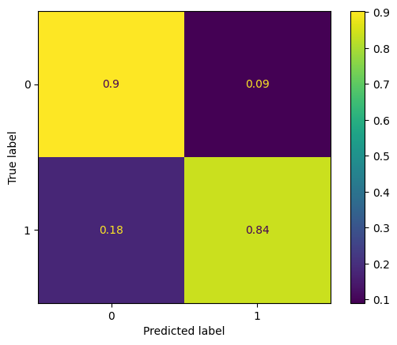

```python
from sklearn.linear_model import LogisticRegression
from sklearn.model_selection import GridSearchCV

def predict_lr(input, test_input):
    lr = LogisticRegression()
    lr.fit(input, train['PurchaseRate'])
    prediction = lr.predict(test_input)

    display_confusion_matrix(test['PurchaseRate'], prediction)

predict_lr(input, test_input)
```

### KNN

KNN algorithm defines K neighbors in train data for each node of test set and predicts by assigning most common label among those K neighbors. K is a predefine constant which will be optimized in the next section.

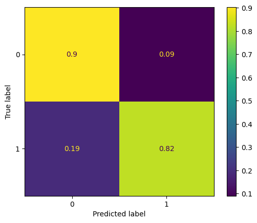

```python
from sklearn.neighbors import KNeighborsClassifier

def predict_knn(input, test_input):
    knn = KNeighborsClassifier(n_neighbors=10)
    knn.fit(input, train['PurchaseRate'])
    prediction = knn.predict(test_input)

    display_confusion_matrix(test['PurchaseRate'], prediction)

predict_knn(input, test_input)
```

### Decision Tree

Decision Tree algorithm (as discussed in the course) is a classification algorithm that splits data into subsets using features.

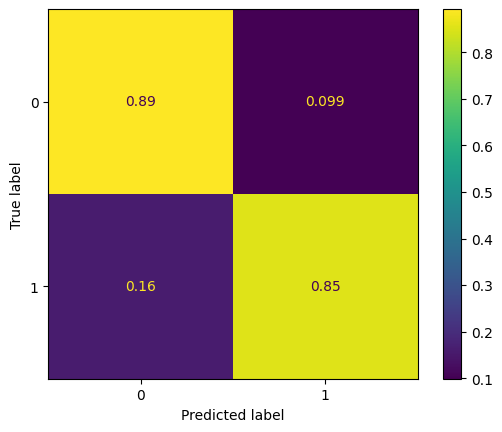

```python
from sklearn.tree import DecisionTreeClassifier
from sklearn.neighbors import KNeighborsClassifier

def predict_dt(input, test_input):
    dt = DecisionTreeClassifier(random_state=10)
    dt.fit(input, train['PurchaseRate'])
    prediction = dt.predict(test_input)

    display_confusion_matrix(test['PurchaseRate'], prediction)

predict_dt(input, test_input)
```

20. Hyperparameters are optimized using GridSearchCV. Range of search that was originally used was wider but since it takes a long time to find the best results, range has been minimized after finding optimal solutions.

### Logistic Regression

```python
lr = LogisticRegression()

grid_search = GridSearchCV(lr, {'max_iter': [10, 100, 1000, 10000] ,'solver':["lbfgs", "newton-cg", "liblinear", "sag", "saga"],
                                    'penalty': ['l1', 'l2', 'elasticnet', None],
                                    'tol': [1e-10, 1e-8, 1e-6, 1e-4, 1e-2]})
grid_search.fit(input, train['PurchaseRate'])
```

```
GridSearchCV(estimator=LogisticRegression(),
             param_grid={'max_iter': [10, 100, 1000, 10000],
                         'penalty': ['l1', 'l2', 'elasticnet', None],
                         'solver': ['lbfgs', 'newton-cg', 'liblinear', 'sag',
                                    'saga'],
                         'tol': [1e-10, 1e-08, 1e-06, 0.0001, 0.01]})
```

```python
print('for linear regression best parameters are: ', grid_search.best_params_ , ' and best score is: ',grid_search.best_score_)
```

```
for linear regression best parameters are:  {'max_iter': 10, 'penalty': None, 'solver': 'newton-cg', 'tol': 1e-10}  and best score is:  0.9062464013943139
```

### KNN

```python
knn = KNeighborsClassifier()
grid_search = GridSearchCV(knn, {'n_neighbors': range(100)})
grid_search.fit(input, train['PurchaseRate'])
```

```
GridSearchCV(estimator=KNeighborsClassifier(),
             param_grid={'n_neighbors': range(0, 100)})
```

```python
print('for KNN best parameters are: ', grid_search.best_params_ , ' and best score is: ',grid_search.best_score_)
```

```
for KNN best parameters are:  {'n_neighbors': 29}  and best score is:  0.8850375811145174
```

### Decision Tree

```python
dt = DecisionTreeClassifier()

grid_search = GridSearchCV(dt, {'random_state': [1],
                                'criterion': ['gini', 'entropy', 'log_loss'],
                                'max_depth': range(1,1000, 20)})
grid_search.fit(input, train['PurchaseRate'])
```

```
GridSearchCV(estimator=DecisionTreeClassifier(),
             param_grid={'criterion': ['gini', 'entropy', 'log_loss'],
                         'max_depth': range(1, 1000, 20), 'random_state': [1]})
```

```python
print('for decision tree best parameters are: ', grid_search.best_params_ , ' and best score is: ',grid_search.best_score_)
```

```
for decision tree best parameters are:  {'criterion': 'entropy', 'max_depth': 21, 'random_state': 1}  and best score is:  0.8973171908311416
```

21. - Overfitting happens when model learns data so well that it starts to model the noise instead of patterns. If a model trains for more iterations than needed or has too many features, overfitting can occur.
    - Underfitting is simply the opposit of overfitting. If model uses too few features to find patterns or trains for fewer iterations than needed, underfitting occurs and model performs poorly.
22. no
23. Decision tree is plotted below:

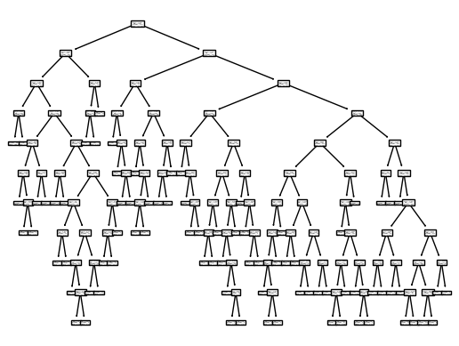

```python
from sklearn import tree
dt= DecisionTreeClassifier(criterion='gini', max_depth=10, random_state= 62)
dt.fit(input, train['PurchaseRate'])
tree_plt = tree.plot_tree(dt)
```

## Random Forest

24. Hyperparameters 'n_estimators' and 'max_depth' are optimized in this part. n_estimators is the number of trees used in the forest and max_depth is the depth of tree.

```python
from sklearn.ensemble import RandomForestClassifier

all_scores = []
for n_est in range(1,21,1):
    scores = []
    for max_dpt in range(1,21,1):
        rf = RandomForestClassifier(max_depth=max_dpt, n_estimators=n_est, random_state=2)
        rf.fit(input, train['PurchaseRate'])
        scores.append(rf.score(test_input, test['PurchaseRate']))
    all_scores.append(scores)
```

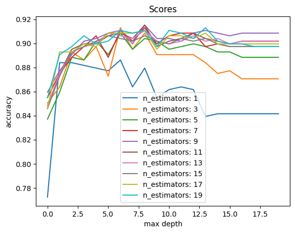

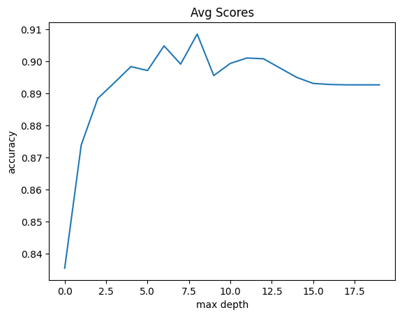

```python
for i in range(1, 21, 2):
    plt.plot(all_scores[i], label = 'n_estimators: %s'%(i))
plt.legend()
plt.title('Scores')
plt.xlabel('max depth')
plt.ylabel('accuracy')
plt.show()

mean = []
for i in range(20):
    mean.append(np.array(all_scores)[:,i].sum()/20)
plt.plot(mean)
plt.title('Avg Scores')
plt.xlabel('max depth')
plt.ylabel('accuracy')
plt.show()
```

25. Apart from not overfitting (which is explained in q24), random forest is more accurate than decision tree despite not being optimized using tools. This too, is a result of combining several trees and relying on more than one model.

    Bias is greatly affected by the model. If model makes wrong or too few assumptions about patterns, bias will go higher. Variance on the other hand, is a measure that shows difference between predictions and train data. Variance will differ if train data is changed. High variance can occur when model is overfit or underfit.

    It's logical to conclude that random forest will have less variance since the model doesn't overfit. Also the bias of random forest is less than decision tree and only downside of this model compared to decision tree is time complexity.

```python
from mlxtend.evaluate import bias_variance_decomp

_, bias, variance = bias_variance_decomp(dt, input.to_numpy(), train['PurchaseRate'].to_numpy(), test_input.to_numpy(), test['PurchaseRate'].to_numpy(), random_seed=1)

print('for decision tree bias is: ', bias, ' and variance is: ', variance)
```

```
for decision tree bias is:  0.08705357142857142  and variance is:  0.07540178571428571
```

```python
rf = RandomForestClassifier(max_depth=12, n_estimators=7, random_state=2)
rf.fit(input, train['PurchaseRate'])
_, bias, variance = bias_variance_decomp(rf, input.to_numpy(), train['PurchaseRate'].to_numpy(), test_input.to_numpy(), test['PurchaseRate'].to_numpy(), random_seed=1)
print('for random tree bias is: ', bias, ' and variance is: ', variance)
```

```
for random tree bias is:  0.08482142857142858  and variance is:  0.03832589285714285
```

as expected, variance is much smaller in random tree and it's bias is better that decision tree.

## Differential Privacy

26. Differential Privacy adds statistical noise to data that is collected. This noise changes data to mask sensitive information, not allowing data from each individual to be identifiable and therefore ensuring privacy. Noise must be small enough to maintain model performance.
27. Laplace Mechanism: In this method, the noise has Laplace distribution (which is a symmetric version of exponential distribution). Laplace Distribution tends to converge to zero slower than Gaussian method.

```python
display(dropped_dataset)
categorical_cols = ['Education', 'PurchaseRate', 'NumPurchases', 'Martial_Status', ]
noise = np.random.normal(0,0.1, dropped_dataset.loc[:,~dropped_dataset.columns.isin(categorical_cols)].shape)
private_data = dropped_dataset
private_data.loc[:,~dropped_dataset.columns.isin(categorical_cols)] = dropped_dataset.loc[:,~dropped_dataset.columns.isin(categorical_cols)] + noise
display(private_data)
```

|  | Year_Birth | Education | Marital_Status | Income | Kidhome | Teenhome | Recency | MntCoffee | MntFruits | MntMeatProducts | MntFishProducts | MntSweetProducts | MntGoldProds | NumWebVisitsMonth | Complain | NumPurchases | UsedCampaignOffer | PurchaseRate |
| --- | --- | --- | --- | --- | --- | --- | --- | --- | --- | --- | --- | --- | --- | --- | --- | --- | --- | --- |
| 0 | -0.985345 | 1 | 1 | 0.241038 | -0.777134 | -0.929894 | 0.307039 | 1.028416 | 1.551577 | 1.679702 | 2.462147 | 1.476500 | 0.853436 | 0.000000 | -0.097282 | 25 | 1.636509 | 1 |
| 1 | -1.235733 | 1 | 1 | -0.245667 | 0.997361 | 0.906934 | -0.383664 | 0.000000 | -0.636301 | -0.713225 | -0.650449 | -0.631503 | -0.731575 | -0.140487 | -0.097282 | 6 | -0.611057 | 0 |
| 2 | -0.317643 | 1 | 2 | 0.797114 | -0.777134 | -0.929894 | -0.798086 | 0.000000 | 0.570804 | -0.177032 | 1.345274 | -0.146905 | -0.035716 | 0.000000 | -0.097282 | 21 | -0.611057 | 1 |
| 3 | 1.268149 | 1 | 2 | -1.058548 | 0.997361 | -0.929894 | -0.798086 | -0.911752 | -0.560857 | -0.651187 | -0.503974 | -0.583043 | -0.750904 | 0.289189 | -0.097282 | 8 | -0.611057 | 0 |
| 4 | 1.017761 | 2 | 3 | 0.247435 | 0.997361 | -0.929894 | 1.550305 | -0.408055 | 0.419916 | -0.216914 | 0.155164 | -0.001525 | -0.557610 | -0.140487 | -0.097282 | 19 | -0.611057 | 1 |
| ... | ... | ... | ... | ... | ... | ... | ... | ... | ... | ... | ... | ... | ... | ... | ... | ... | ... | ... |
| 2235 | -0.150717 | 1 | 3 | 0.368348 | -0.777134 | 0.906934 | -0.107383 | 1.258500 | 0.419916 | 0.066692 | 0.081926 | 2.203398 | 3.926810 | -0.140487 | -0.097282 | 18 | -0.611057 | 1 |
| 2236 | -1.903435 | 2 | 2 | 0.483524 | 2.771857 | 0.906934 | 0.237969 | 0.316399 | -0.661449 | -0.606873 | -0.687068 | -0.655733 | -0.692916 | 0.718865 | -0.097282 | 22 | 1.636509 | 1 |
| 2237 | 1.017761 | 1 | 4 | 0.193292 | -0.777134 | -0.929894 | 1.446700 | 1.877239 | 0.545656 | 0.221789 | -0.101168 | -0.364974 | -0.383646 | 0.289189 | -0.097282 | 19 | 1.636509 | 1 |
| 2238 | -1.068807 | 3 | 2 | 0.699393 | -0.777134 | 0.906934 | -1.419719 | 0.384802 | 0.092992 | 0.208495 | 0.777683 | 0.071165 | 0.331542 | 0.000000 | -0.097282 | 23 | -0.611057 | 1 |
| 2239 | -1.235733 | 2 | 3 | 0.023602 | 0.997361 | 0.906934 | -0.314594 | -0.684778 | -0.586005 | -0.469501 | -0.650449 | -0.631503 | -0.441634 | 0.718865 | -0.097282 | 11 | 1.636509 | 0 |

2240 rows × 18 columns

|  | Year_Birth | Education | Marital_Status | Income | Kidhome | Teenhome | Recency | MntCoffee | MntFruits | MntMeatProducts | MntFishProducts | MntSweetProducts | MntGoldProds | NumWebVisitsMonth | Complain | NumPurchases | UsedCampaignOffer | PurchaseRate |
| --- | --- | --- | --- | --- | --- | --- | --- | --- | --- | --- | --- | --- | --- | --- | --- | --- | --- | --- |
| 0 | -1.004408 | 1 | 1.222251 | 0.092953 | -0.860670 | -1.143097 | 0.325369 | 1.146266 | 1.453906 | 1.880168 | 2.525977 | 1.301782 | 0.834303 | -0.130658 | -0.142831 | 25 | 1.642396 | 1 |
| 1 | -1.308196 | 1 | 0.957709 | -0.253738 | 0.935434 | 1.073237 | -0.502247 | -0.074126 | -0.572515 | -0.751692 | -0.710637 | -0.557202 | -0.588541 | -0.250991 | -0.087307 | 6 | -0.694790 | 0 |
| 2 | -0.181786 | 1 | 1.930778 | 0.812032 | -0.904152 | -0.893780 | -0.824794 | 0.062074 | 0.652018 | -0.119224 | 1.471821 | -0.039519 | -0.054671 | 0.068431 | -0.131705 | 21 | -0.720234 | 1 |
| 3 | 1.247259 | 1 | 2.164480 | -0.933598 | 1.063656 | -0.911166 | -0.977743 | -1.038809 | -0.671447 | -0.652492 | -0.425915 | -0.527571 | -0.682229 | 0.025933 | 0.019573 | 8 | -0.494125 | 0 |
| 4 | 1.145015 | 2 | 2.917708 | 0.246754 | 0.899633 | -0.679448 | 1.565438 | -0.407109 | 0.450524 | -0.294898 | 0.188851 | 0.083595 | -0.524518 | -0.196373 | -0.113283 | 19 | -0.362220 | 1 |
| ... | ... | ... | ... | ... | ... | ... | ... | ... | ... | ... | ... | ... | ... | ... | ... | ... | ... | ... |
| 2235 | -0.171158 | 1 | 3.021186 | 0.440300 | -0.859587 | 0.814644 | -0.249580 | 1.245261 | 0.408818 | 0.134030 | 0.140943 | 2.288853 | 4.107768 | -0.151442 | 0.071762 | 18 | -0.570145 | 1 |
| 2236 | -1.813800 | 2 | 1.813380 | 0.541120 | 3.078471 | 1.116706 | 0.171400 | 0.285239 | -0.769845 | -0.649665 | -0.900992 | -0.645124 | -0.626965 | 0.872795 | -0.244179 | 22 | 1.694789 | 1 |
| 2237 | 1.021328 | 1 | 4.070621 | 0.157482 | -0.829718 | -0.898794 | 1.339904 | 1.934033 | 0.586536 | 0.117830 | -0.254014 | -0.440064 | -0.547464 | 0.331190 | -0.102963 | 19 | 1.526002 | 1 |
| 2238 | -0.929804 | 3 | 2.057745 | 0.675212 | -0.951646 | 0.879203 | -1.447937 | 0.318328 | -0.077589 | 0.220389 | 0.893365 | 0.014639 | 0.278693 | -0.031182 | -0.094607 | 23 | -0.562155 | 1 |
| 2239 | -1.318062 | 2 | 3.090412 | 0.052981 | 0.849468 | 0.887798 | -0.345417 | -0.882569 | -0.447116 | -0.376753 | -0.648570 | -0.612713 | -0.659674 | 0.723031 | 0.062048 | 11 | 1.679977 | 0 |

2240 rows × 18 columns

### LR

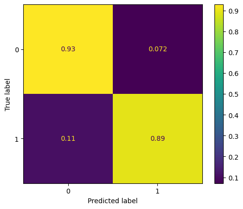

```python
train, test = get_train_test(private_data)

input = train.loc[:, ~train.columns.isin(['PurchaseRate', 'NumPurchases'])]
test_input = test.loc[:, ~train.columns.isin(['PurchaseRate', 'NumPurchases'])]

predict_lr(input, test_input)
```

### KNN

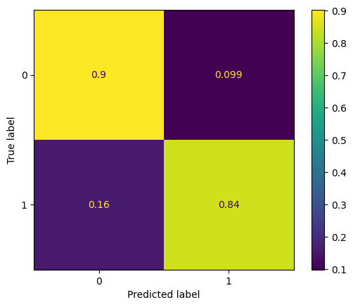

```python
predict_knn(input, test_input)
```

### DT

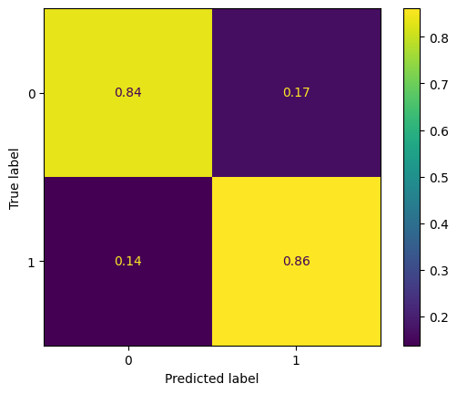

```python
predict_dt(input, test_input)
```

### Random Forest

```python
rf = RandomForestClassifier(max_depth=10, n_estimators=7, random_state=2)
rf.fit(input, train['PurchaseRate'])
rf.score(test_input, test['PurchaseRate'])
```

```
0.9017857142857143
```

# Gradient-Boosting

29. Gradient Boosting is a powerful method for boosting prediction models. It combines multiple weak makes into a single powerful model. Difference between GB and Random Forest algorithm is that random forest simply combines multiple trees by finding mean value of prediction, but gradient boosting tries to correct each model's error with another model. First a model predicts the outputs, and then errors of predictions are given to another model, which tries to correct the errors and this process continues.
30. XGBoost is a boosting algorithm that uses gradient boosting to solve classification problems. This algorithm allows users to choose different hypermeters to optimize boosting process. Hyperparameters include 'booster' which indicates the model it is going to use, 'gamma' which is the minimum loss reduction, 'max_depth' which is self explanatory.
31. XGBoost is optimized below. Best score of this algorithm is 91% which is better than random forest even after implementing the noise.

```python
from xgboost import XGBClassifier

xgb = XGBClassifier()

grid_search = GridSearchCV(xgb, {'random_state': [1],
                                'booster': ['gbtree', 'gblinear', 'dart'],
                                'gamma': [0,100,10],
                                'max_depth': range(1,1000, 100)})
grid_search.fit(input, train['PurchaseRate'])
```

```
GridSearchCV(estimator=XGBClassifier(base_score=None, booster=None,
                                     callbacks=None, colsample_bylevel=None,
                                     colsample_bynode=None,
                                     colsample_bytree=None, device=None,
                                     early_stopping_rounds=None,
                                     enable_categorical=False, eval_metric=None,
                                     feature_types=None, gamma=None,
                                     grow_policy=None, importance_type=None,
                                     interaction_constraints=None,
                                     learning_rate=None, max_b...
                                     max_cat_to_onehot=None,
                                     max_delta_step=None, max_depth=None,
                                     max_leaves=None, min_child_weight=None,
                                     missing=nan, monotone_constraints=None,
                                     multi_strategy=None, n_estimators=None,
                                     n_jobs=None, num_parallel_tree=None,
                                     random_state=None, ...),
             param_grid={'booster': ['gbtree', 'gblinear', 'dart'],
                         'gamma': [0, 100, 10],
                         'max_depth': range(1, 1000, 100),
                         'random_state': [1]})
```

```python
print('for xgboost best score is: ',grid_search.best_score_)
```

```
for xgboost best score is:  0.9118329935730849
```